# Biometry activity 1

Madeleine Schoderbek

2025-09-22

```r
Cpap <- read.csv(file = "data/CPAPAdherence_Data.csv")
```

```r
Cpap <- read.csv(file = "data/CPAPAdherence_Data.csv" )
```

1. There is a data entry error for finding the ages of the dataset. I find that there are ages above 500 all the way to 600 in this data set, which is not possible.

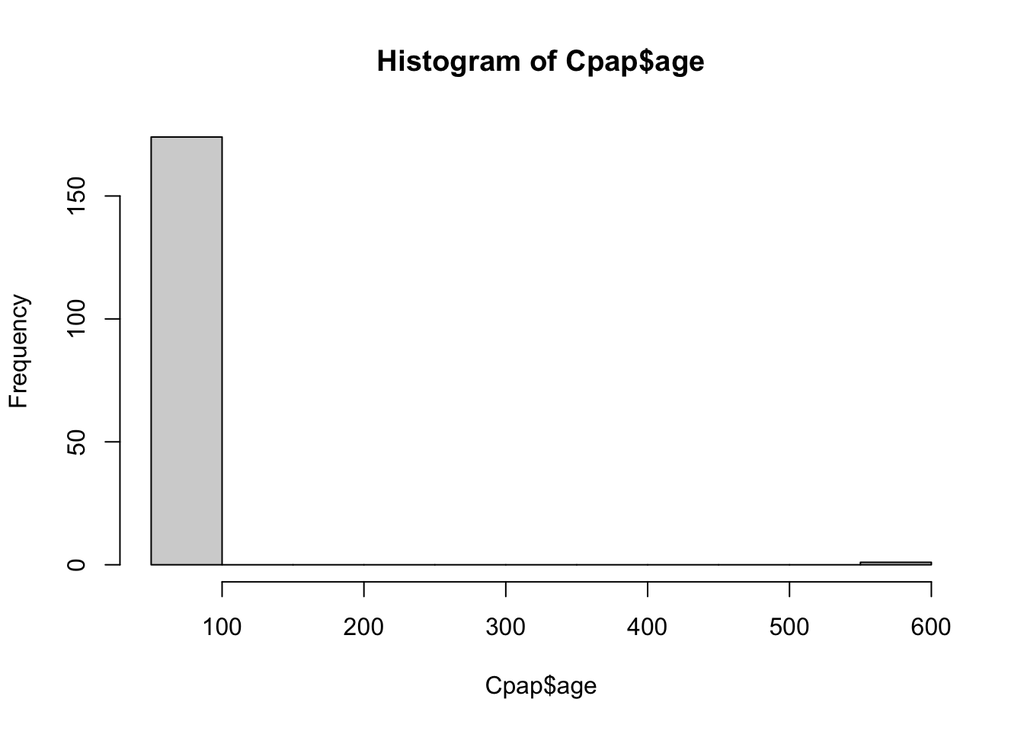

```r
hist(Cpap$age)
```

```r
weirdAges <- which(Cpap$age >= 100)
print(x = weirdAges)
```

```
## [1] 5
```

```r
Cpap$age[weirdAges]
```

```
## [1] 555
```

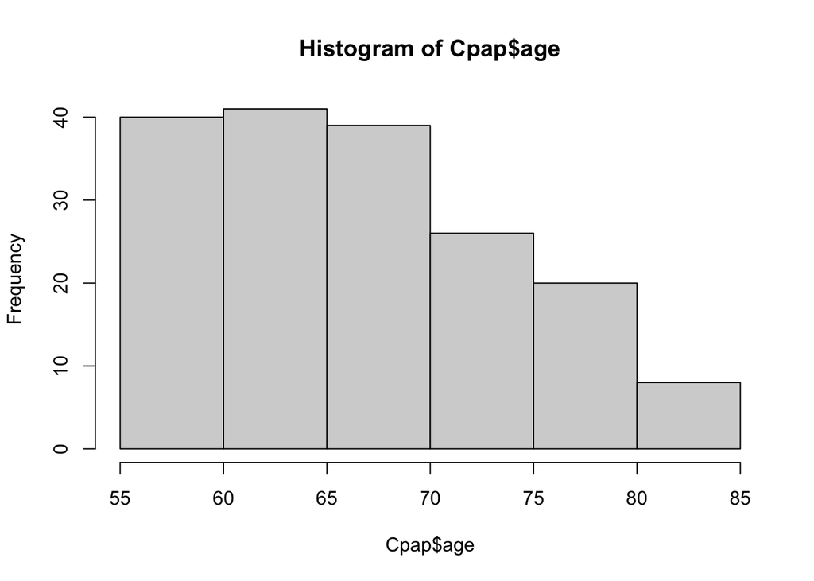

```r
removeAges <- which(Cpap$age > 110)
Cpap <- Cpap[-removeAges, ]
hist(Cpap$age)
```

2. When looking at the table for race_white, I find that there is a third column labeled “q”. When in the data dictionary it indicates that there should only be 2 columns: 1 = yes, 0 = no

```r
table(Cpap$race_white)
```

```
##
##   0   1   q
##  49 124   1
```

```r
removerace_white <- which(Cpap$race_white == "q")
Cpap$race_white[removerace_white] <- NA
table(Cpap$race_white)
```

```
##
##   0   1
##  49 124
```

3. When looking at the table for race_other, I find that there is a third column labeled “p”. When in the data dictionary it indicates that there should only be 2 columns: 1 = yes, 0 = no

```r
table(Cpap$race_other)
```

```
##
##   0   1   p
## 161  12   1
```

```r
removerace_other <- which(Cpap$race_other == "p")
Cpap$race_other[removerace_other] <- NA
table(Cpap$race_other)
```

```
##
##   0   1
## 161  12
```

4. When looking at the table for sex, I find that there are 3 columns: 0, 1, 2 with corresponding numbers of sex under each column. When the data dictionary indicates that there should only be 2 columns for sex: 1 = female and 0 = male.

```r
table(Cpap$sex)
```

```
##
##  0  1  2
## 95 78  1
```

```r
removesex <- which(Cpap$sex == 2)
Cpap$sex[removesex] <- NA
table(Cpap$sex)
```

```
##
##  0  1
## 95 78
```

5. When looking at education, I find that there is a random value indicated in the table showing a 1.

```r
table(Cpap$education)
```

```
##
##                <= high school  > high school
##              1             36            137
```

```r
removeeducation <- which(Cpap$education == "")
Cpap$education[removeeducation] <- NA
table(Cpap$education)
```

```
##
## <= high school  > high school
##             36            137
```

6. When looking at the histogram graph for ess (Measure of day time sleepiness), the information for values 25-30 are inaccurate because it is indicated on the data dictionary that the maximum possible number of daytime sleepiness is 24, when on the x-axis it reaches over 24 to 30.

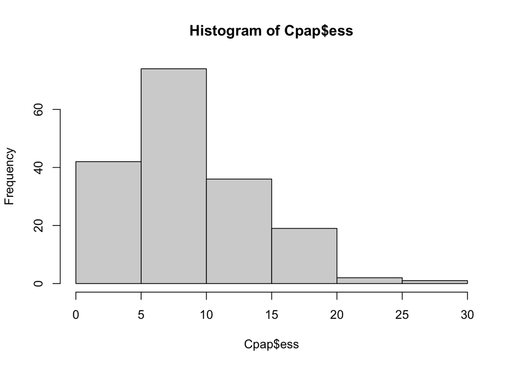

```r
hist(Cpap$ess)
```

```r
weirdess <- which(Cpap$ess >= 24)
print(x = weirdess)
```

```
## [1] 21
```

```r
Cpap$ess[weirdess]
```

```
## [1] 30
```

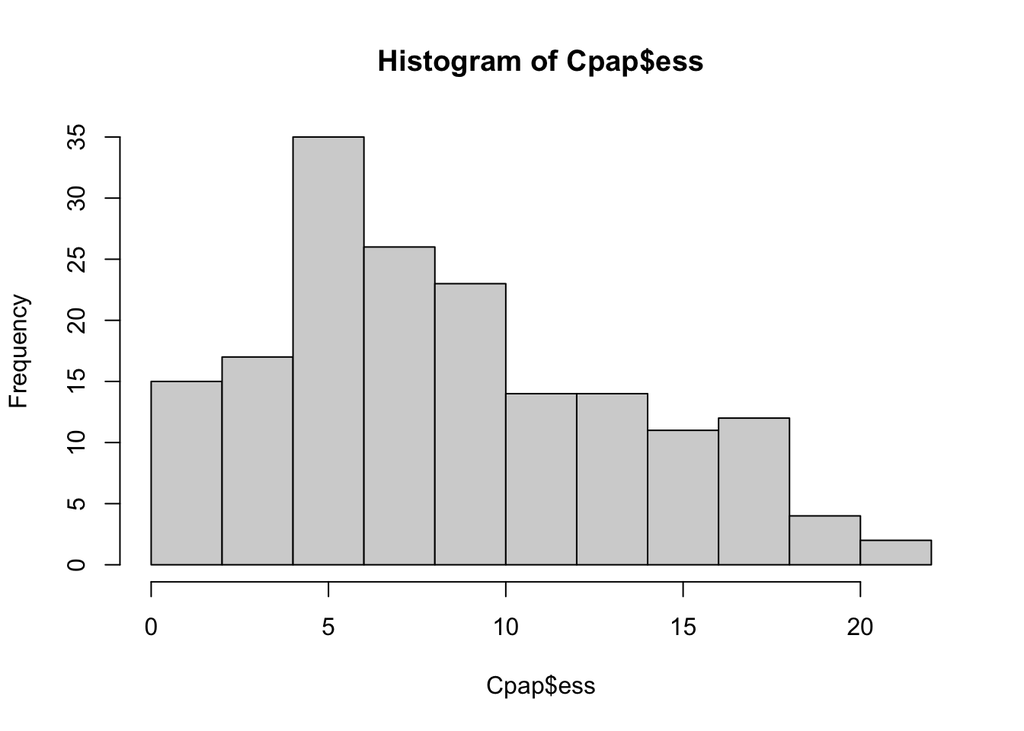

```r
removeess <- which(Cpap$ess > 24)
Cpap <- Cpap[-removeess,]
hist(Cpap$ess)
```

7. When looking at the histogram graph for avg daily cpap, we find that there is a value of over 20 hours of sleep which is an obvious outlier in the data.

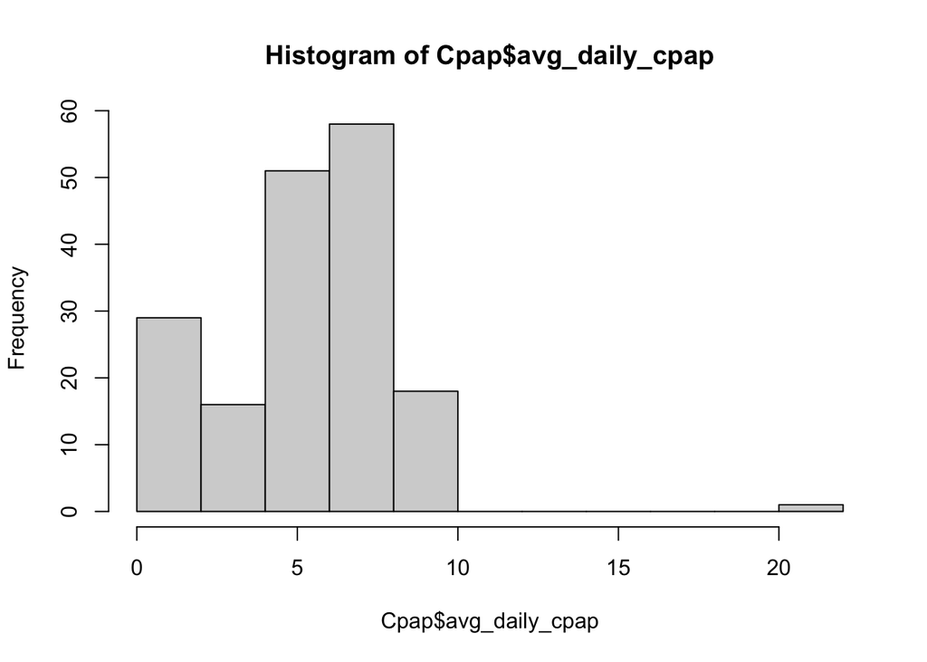

```r
hist(Cpap$avg_daily_cpap)
```

```r
weirdavg_daily_cpap <- which(Cpap$avg_daily_cpap >= 20)
print(x = weirdavg_daily_cpap)
```

```
## [1] 63
```

```r
Cpap$avg_daily_cpap[weirdavg_daily_cpap]
```

```
## [1] 21.16667
```

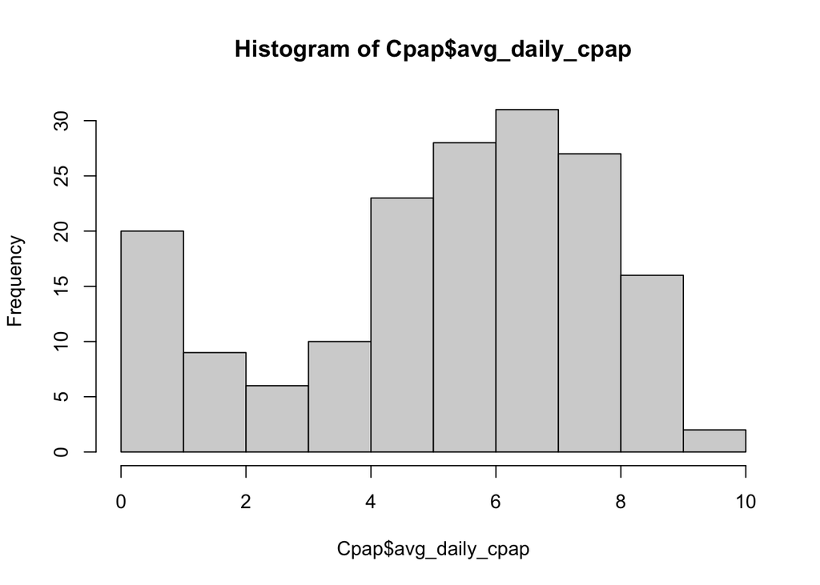

```r
removeavg_daily_cpap <- which(Cpap$avg_daily_cpap > 20)
Cpap <- Cpap[-removeavg_daily_cpap,]
hist(Cpap$avg_daily_cpap)
```

8. When looking at subject ID for the dataset. I find that there is a duplicate subject ID for lines 124 and 125. By finding the duplicate subject I can remove it from the dataset.

```r
table(Cpap$subject_id)
```

```
##
## 11-01102 11-01153 11-01442 11-01634 11-01777 11-01785 11-01796 11-01881
##        1        1        1        1        1        1        1        1
## 11-02023 11-02116 11-02471 11-02480 11-02649 11-02727 11-02828 11-03413
##        1        1        1        1        1        1        1        1
## 11-03539 11-03552 11-04223 11-04386 11-05256 11-05490 11-05535 11-05547
##        1        1        1        1        1        1        1        1
## 11-06113 11-06785 11-07113 11-07374 11-07491 11-07498 11-08435 11-08637
##        1        1        1        1        1        1        1        1
## 11-09207 12-00012 12-00092 12-00152 12-00211 12-00266 12-00275 12-00357
##        1        1        1        1        1        1        1        1
## 12-00433 12-00434 12-00437 12-00440 12-00441 12-00449 12-00452 12-00456
##        1        1        1        1        1        1        1        1
## 12-00458 12-00459 12-00468 12-00475 12-00481 12-00483 12-00490 12-00491
##        1        1        1        1        1        1        1        1
## 12-00495 12-00510 12-00533 12-00534 12-00546 12-00562 12-00570 12-00595
##        1        1        1        1        1        1        1        1
## 12-00607 12-00613 12-00630 12-00651 12-00654 12-00675 12-00678 12-00682
##        1        1        1        1        1        1        1        1
## 12-00707 12-00718 12-00731 12-00738 12-00743 12-00751 12-00752 12-00756
##        1        1        1        1        1        1        1        1
## 12-00763 12-00764 12-00793 12-00814 12-00827 12-00863 12-00869 12-00893
##        1        1        1        1        1        1        1        1
## 12-00898 12-00901 12-00929 12-00936 12-00968 12-00977 12-01042 14-00004
##        1        1        1        1        1        1        1        1
## 14-00023 14-00036 14-00051 14-00054 14-00065 14-00071 14-00081 14-00150
##        1        1        1        1        1        1        1        1
## 14-00215 14-00245 14-00249 14-00307 14-00343 14-00344 14-00361 15-00092
##        1        1        1        1        1        1        1        1
## 15-00142 15-00268 15-00279 15-00281 15-00533 15-00546 15-00583 15-00584
##        1        1        1        1        1        1        1        1
## 15-00609 15-00654 15-00676 15-00721 15-00737 15-00948 15-00952 15-00964
##        2        1        1        1        1        1        1        1
## 15-01078 15-01167 15-01191 15-01278 15-01302 15-01303 15-01346 15-01364
##        1        1        1        1        1        1        1        1
## 15-01388 15-01409 15-01473 15-01543 15-01583 15-01620 15-01783 15-01808
##        1        1        1        1        1        1        1        1
## 15-01862 15-01880 15-01896 15-01932 15-01989 15-02241 15-02245 15-02250
##        1        1        1        1        1        1        1        1
## 15-02283 15-02331 15-02365 15-02388 15-02407 15-02430 15-02437 15-02481
##        1        1        1        1        1        1        1        1
## 15-02517 15-02526 15-02537 15-02540 15-02548 15-02601 15-02621 16-02424
##        1        1        1        1        1        1        1        1
## 16-05660 16-07377 16-07388
##        1        1        1
```

```r
duplicated(x = Cpap$subject_id)
```

```
##   [1] FALSE FALSE FALSE FALSE FALSE FALSE FALSE FALSE FALSE FALSE FALSE FALSE
##  [13] FALSE FALSE FALSE FALSE FALSE FALSE FALSE FALSE FALSE FALSE FALSE FALSE
##  [25] FALSE FALSE FALSE FALSE FALSE FALSE FALSE FALSE FALSE FALSE FALSE FALSE
##  [37] FALSE FALSE FALSE FALSE FALSE FALSE FALSE FALSE FALSE FALSE FALSE FALSE
##  [49] FALSE FALSE FALSE FALSE FALSE FALSE FALSE FALSE FALSE FALSE FALSE FALSE
##  [61] FALSE FALSE FALSE FALSE FALSE FALSE FALSE FALSE FALSE FALSE FALSE FALSE
##  [73] FALSE FALSE FALSE FALSE FALSE FALSE FALSE FALSE FALSE FALSE FALSE FALSE
##  [85] FALSE FALSE FALSE FALSE FALSE FALSE FALSE FALSE FALSE FALSE FALSE FALSE
##  [97] FALSE FALSE FALSE FALSE FALSE FALSE FALSE FALSE FALSE FALSE FALSE FALSE
## [109] FALSE FALSE FALSE FALSE FALSE FALSE FALSE FALSE FALSE FALSE FALSE FALSE
## [121] FALSE  TRUE FALSE FALSE FALSE FALSE FALSE FALSE FALSE FALSE FALSE FALSE
## [133] FALSE FALSE FALSE FALSE FALSE FALSE FALSE FALSE FALSE FALSE FALSE FALSE
## [145] FALSE FALSE FALSE FALSE FALSE FALSE FALSE FALSE FALSE FALSE FALSE FALSE
## [157] FALSE FALSE FALSE FALSE FALSE FALSE FALSE FALSE FALSE FALSE FALSE FALSE
## [169] FALSE FALSE FALSE FALSE
```

```r
which(duplicated(x = Cpap$subject_id))
```

```
## [1] 122
```

```r
print(x = Cpap[120:130, ])
```

```
##     subject_id              ethnicity      education race_black race_white
## 123   15-00584 Not Hispanic or Latino  > high school          0          1
## 124   15-00609 Not Hispanic or Latino  > high school          0          1
## 125   15-00609 Not Hispanic or Latino  > high school          0          1
## 126   15-00654 Not Hispanic or Latino  > high school          0          1
## 127   15-00676 Not Hispanic or Latino  > high school          0          1
## 128   15-00721 Not Hispanic or Latino <= high school          0          1
## 129   15-00737 Not Hispanic or Latino  > high school          0          1
## 130   15-00948 Not Hispanic or Latino  > high school          0          1
## 131   15-00952 Not Hispanic or Latino  > high school          1          0
## 132   15-00964 Not Hispanic or Latino  > high school          1          0
## 133   15-01078 Not Hispanic or Latino  > high school          0          1
##     race_other age sex  ahi ess mmse avg_daily_cpap
## 123          0  67   1 72.9   8   30       6.116667
## 124          0  63   0 21.2   8   30       4.716667
## 125          0  63   0 21.2   8   30       4.716667
## 126          0  68   1 15.6   3   28       5.633333
## 127          0  61   1 67.0   4   28       6.950000
## 128          0  67   0 16.0  12   30       5.700000
## 129          0  64   1 15.0  20   28       6.100000
## 130          0  64   0 24.8   6   29       8.616667
## 131          0  67   1 51.4  16   28       1.883333
## 132          0  69   1 48.3  18   28       0.150000
## 133          0  66   1 94.8  13   27       5.666667
```

```r
dup <- which(duplicated(Cpap$subject_id))
Cpap <- Cpap[-dup,]
print(x = Cpap$subject_id)
```

```
##   [1] "11-01102" "11-01153" "11-01442" "11-01634" "11-01777" "11-01785"
##   [7] "11-01796" "11-01881" "11-02023" "11-02116" "11-02471" "11-02480"
##  [13] "11-02649" "11-02727" "11-02828" "11-03413" "11-03539" "11-03552"
##  [19] "11-04223" "11-04386" "11-05256" "11-05490" "11-05535" "11-05547"
##  [25] "11-06113" "11-06785" "11-07113" "11-07374" "11-07491" "11-07498"
##  [31] "11-08435" "11-08637" "11-09207" "12-00012" "12-00092" "12-00152"
##  [37] "12-00211" "12-00266" "12-00275" "12-00357" "12-00433" "12-00434"
##  [43] "12-00437" "12-00440" "12-00441" "12-00449" "12-00452" "12-00456"
##  [49] "12-00458" "12-00459" "12-00468" "12-00475" "12-00481" "12-00483"
##  [55] "12-00490" "12-00491" "12-00495" "12-00510" "12-00533" "12-00534"
##  [61] "12-00546" "12-00562" "12-00570" "12-00595" "12-00607" "12-00613"
##  [67] "12-00630" "12-00651" "12-00654" "12-00675" "12-00678" "12-00682"
##  [73] "12-00707" "12-00718" "12-00731" "12-00738" "12-00743" "12-00751"
##  [79] "12-00752" "12-00756" "12-00763" "12-00764" "12-00793" "12-00814"
##  [85] "12-00827" "12-00863" "12-00869" "12-00893" "12-00898" "12-00901"
##  [91] "12-00929" "12-00936" "12-00968" "12-00977" "12-01042" "14-00004"
##  [97] "14-00023" "14-00036" "14-00051" "14-00054" "14-00065" "14-00071"
## [103] "14-00081" "14-00150" "14-00215" "14-00245" "14-00249" "14-00307"
## [109] "14-00343" "14-00344" "14-00361" "15-00092" "15-00142" "15-00268"
## [115] "15-00279" "15-00281" "15-00533" "15-00546" "15-00583" "15-00584"
## [121] "15-00609" "15-00654" "15-00676" "15-00721" "15-00737" "15-00948"
## [127] "15-00952" "15-00964" "15-01078" "15-01167" "15-01191" "15-01278"
## [133] "15-01302" "15-01303" "15-01346" "15-01364" "15-01388" "15-01409"
## [139] "15-01473" "15-01543" "15-01583" "15-01620" "15-01783" "15-01808"
## [145] "15-01862" "15-01880" "15-01896" "15-01932" "15-01989" "15-02241"
## [151] "15-02245" "15-02250" "15-02283" "15-02331" "15-02365" "15-02388"
## [157] "15-02407" "15-02430" "15-02437" "15-02481" "15-02517" "15-02526"
## [163] "15-02537" "15-02540" "15-02548" "15-02601" "15-02621" "16-02424"
## [169] "16-05660" "16-07377" "16-07388"
```

# RACE == COMBINING RACE VARIABLES

```r
Cpap$race <- ifelse(Cpap$race_black == 1, "Black",
ifelse(Cpap$race_white == 1, "White",
ifelse(Cpap$race_other == 1, "Other", NA)))

print(x = Cpap$race)
```

```
##   [1] "Black" "White" "White" "White" "White" "Black" "White" "White" "Black"
##  [10] "White" "White" "Black" "White" "White" "Black" "White" "Black" "Black"
##  [19] "Black" "Black" "White" "Other" "White" "Black" "Black" "White" "White"
##  [28] "White" "Black" "White" "Black" "Other" "White" "White" "White" "White"
##  [37] "White" "White" "White" "White" "White" "Other" "White" "Other" "Black"
##  [46] "White" "White" "White" "White" NA      "White" "Black" "White" "White"
##  [55] "White" "White" "White" "White" "White" "White" "White" "White" "White"
##  [64] "White" "White" "Black" "White" "Other" "White" "White" "White" "Black"
##  [73] "Other" "Other" "White" "Other" "Black" "Black" "Other" "White" "Other"
##  [82] "White" "White" "White" "White" "Other" "White" "White" "Black" "Black"
##  [91] "Other" "White" "White" "White" "White" "White" "White" "White" "White"
## [100] "White" "White" "White" "White" "White" "White" "Black" "White" "White"
## [109] "White" "White" "White" "White" "White" "Black" "White" "White" "White"
## [118] "White" "White" "White" "White" "White" "White" "White" "White" "White"
## [127] "Black" "Black" "White" "Black" "White" "Black" "White" "White" "Black"
## [136] "White" "White" "Black" "White" "White" "White" "White" "White" NA
## [145] "Black" "White" "Black" "White" "White" "White" "White" "White" "White"
## [154] "White" "White" "White" "White" "White" "White" "White" "White" "Black"
## [163] "White" "White" "White" "Black" "White" "White" "White" "Black" "Black"
```

```r
table(Cpap$race)
```

```
##
## Black Other White
##    35    12   122
```

#AVG_DAILY_CPAP == CREATING “ADHERENCE VARIABLE”

```r
Cpap$adherence <- ifelse(Cpap$avg_daily_cpap >= 4, "Adherent", "Non-Adherent")

print(x = Cpap$adherence)
```

```
##   [1] "Adherent"     "Adherent"     "Adherent"     "Adherent"     "Adherent"
##   [6] "Non-Adherent" "Adherent"     "Adherent"     "Adherent"     "Adherent"
##  [11] "Non-Adherent" "Non-Adherent" "Adherent"     "Adherent"     "Non-Adherent"
##  [16] "Non-Adherent" "Non-Adherent" "Adherent"     "Non-Adherent" "Non-Adherent"
##  [21] "Non-Adherent" "Adherent"     "Adherent"     "Adherent"     "Adherent"
##  [26] "Non-Adherent" "Adherent"     "Adherent"     "Adherent"     "Adherent"
##  [31] "Non-Adherent" "Non-Adherent" "Non-Adherent" "Non-Adherent" "Adherent"
##  [36] "Non-Adherent" "Adherent"     "Non-Adherent" "Adherent"     "Non-Adherent"
##  [41] "Adherent"     "Adherent"     "Adherent"     "Adherent"     "Non-Adherent"
##  [46] "Adherent"     "Adherent"     "Adherent"     "Non-Adherent" "Adherent"
##  [51] "Adherent"     "Non-Adherent" "Non-Adherent" "Non-Adherent" "Adherent"
##  [56] "Adherent"     "Adherent"     "Adherent"     "Adherent"     "Adherent"
##  [61] "Adherent"     "Adherent"     "Adherent"     "Adherent"     "Adherent"
##  [66] "Adherent"     "Adherent"     "Adherent"     "Adherent"     "Adherent"
##  [71] "Non-Adherent" "Adherent"     "Adherent"     "Adherent"     "Adherent"
```

[output cut: 20 more lines]

# EXAMINING SHAPE OF AHI IN TERMS OF SHAPE AND SKEW

# Using the histogram function for Apnea Hypopnea Index (AHI), using base R I see that this histogram is a positively right skewed distribution. The shape of the histogram is regular and the frequency decreases as the apnea events per hour increases. I see that this display is univariate because the x-axis represents only a single variable. Furthermore, I can also tell that this is univariate being that the y axis shows frequency and there are no groupings shown in the graph.

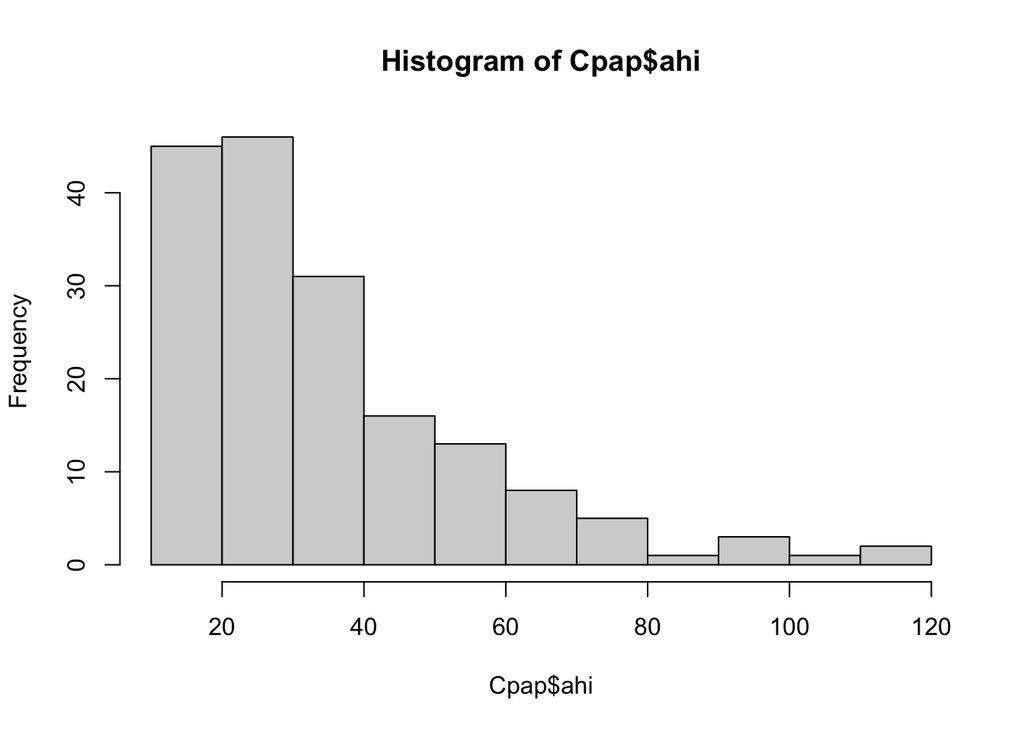

```r
hist(Cpap$ahi)
```

# EXAMINING DISTRIBUTIONS OF AGE VS ADHERENCE

# Using the box plot function for age vs adherence category I can see that this box plot is bivariate because it is comparing 2 variables (adherent vs non-adherent under age). Being that both box plots are about the same width, I can tell that there is not a wide variety of age differences between the two. I can tell that there is a difference in the IQR between the 2 box plots because the adherent boxplot is taller than the non-adherent box plot. I can also see that for the non-adherent box plot, the top whisker is longer than the top whisker of the adherent box plot, this could show that some non-adherent individuals are older than the rest, and the age distribution may be skewed right.

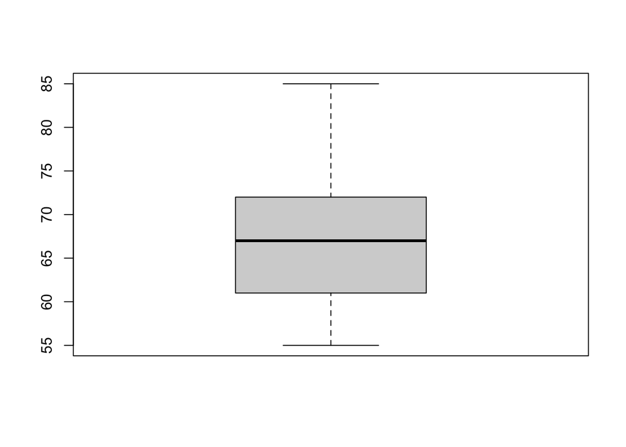

```r
boxplot(Cpap$age)
```

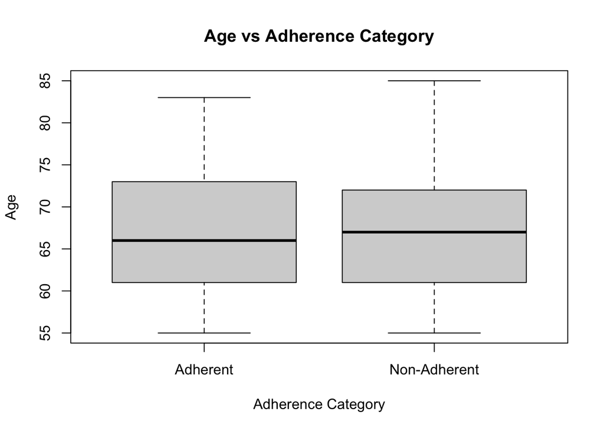

```r
boxplot(age ~ adherence,
data = Cpap,
xlab = "Adherence Category",
ylab = "Age",
main = "Age vs Adherence Category")
```